# Summary of JAGS model

## Run Summary

Chains : 6  
Burn-in : 55000  
Samples per chain : 167  
Total samples : 1002  
Thinning : 1000  
Duration: 2.2 hours  
Start Time: 2026-06-24 17:57  
End Time: 2026-06-24 20:10

## Posterior Summary

|  | Lower95 | Median | Upper95 | Mean | SD | Mode | MCerr | MC%ofSD | SSeff | AC.10000 | psrf |
| --- | --- | --- | --- | --- | --- | --- | --- | --- | --- | --- | --- |
| **deviance** | 44520 | 44574 | 44623 | 44573 | 26.31 | 44572 | 0.8581 | 3.3 | 940 | -0.005311 | 1.003 |
| **sire.vcov[1,1]** | 0.3297 | 1.78 | 4.567 | 2.138 | 1.643 | 1.31 | 0.04703 | 2.9 | 1220 | -0.008387 | 0.9997 |
| **sire.vcov[2,1]** | -4.493 | 0.1401 | 5.711 | 0.3741 | 2.554 | 0.07405 | 0.08018 | 3.1 | 1015 | -0.0007152 | 1.003 |
| **sire.vcov[3,1]** | -0.4359 | 0.2146 | 1.04 | 0.2686 | 0.3663 | 0.1392 | 0.01133 | 3.1 | 1046 | 0.05731 | 1.007 |
| **sire.vcov[4,1]** | -0.7433 | -0.02913 | 0.8121 | -0.0315 | 0.3755 | -0.0295 | 0.01186 | 3.2 | 1002 | 0.02946 | 1.007 |
| **sire.vcov[1,2]** | -4.493 | 0.1401 | 5.711 | 0.3741 | 2.554 | 0.07405 | 0.08018 | 3.1 | 1015 | -0.0007152 | 1.003 |
| **sire.vcov[2,2]** | 0.5512 | 13.61 | 32.88 | 14.78 | 10.12 | 7.201 | 0.304 | 3 | 1108 | 0.002052 | 1.001 |
| **sire.vcov[3,2]** | -1.599 | 0.07825 | 2.041 | 0.1468 | 0.9165 | 0.1266 | 0.02908 | 3.2 | 993 | 0.04472 | 1.003 |
| **sire.vcov[4,2]** | -1.38 | 0.1944 | 2.2 | 0.2915 | 0.9018 | 0.1146 | 0.02516 | 2.8 | 1284 | 0.02563 | 1.001 |
| **sire.vcov[1,3]** | -0.4359 | 0.2146 | 1.04 | 0.2686 | 0.3663 | 0.1392 | 0.01133 | 3.1 | 1046 | 0.05731 | 1.007 |
| **sire.vcov[2,3]** | -1.599 | 0.07825 | 2.041 | 0.1468 | 0.9165 | 0.1266 | 0.02908 | 3.2 | 993 | 0.04472 | 1.003 |
| **sire.vcov[3,3]** | 0.2718 | 0.5868 | 1.122 | 0.6355 | 0.2531 | 0.534 | 0.008435 | 3.3 | 900 | 0.02065 | 1.003 |
| **sire.vcov[4,3]** | -0.33 | 0.02983 | 0.4179 | 0.03192 | 0.181 | 0.03017 | 0.00576 | 3.2 | 988 | -0.02759 | 1.006 |
| **sire.vcov[1,4]** | -0.7433 | -0.02913 | 0.8121 | -0.0315 | 0.3755 | -0.0295 | 0.01186 | 3.2 | 1002 | 0.02946 | 1.007 |
| **sire.vcov[2,4]** | -1.38 | 0.1944 | 2.2 | 0.2915 | 0.9018 | 0.1146 | 0.02516 | 2.8 | 1284 | 0.02563 | 1.001 |
| **sire.vcov[3,4]** | -0.33 | 0.02983 | 0.4179 | 0.03192 | 0.181 | 0.03017 | 0.00576 | 3.2 | 988 | -0.02759 | 1.006 |
| **sire.vcov[4,4]** | 0.2364 | 0.5791 | 1.113 | 0.6286 | 0.2545 | 0.5125 | 0.00804 | 3.2 | 1002 | 0.01456 | 1.003 |
| **dam.vcov[1,1]** | 8.132 | 18.29 | 33.57 | 19.36 | 6.758 | 16.74 | 0.2175 | 3.2 | 965 | -0.002943 | 0.9995 |
| **dam.vcov[2,1]** | 0.8211 | 21.83 | 49.8 | 23.52 | 13.21 | 17.5 | 0.4172 | 3.2 | 1002 | -0.009102 | 1.001 |
| **dam.vcov[3,1]** | -0.4906 | 1.272 | 3.754 | 1.384 | 1.091 | 1.32 | 0.03407 | 3.1 | 1027 | -0.03046 | 1.001 |
| **dam.vcov[4,1]** | -1.663 | 0.2353 | 2.508 | 0.2775 | 1.07 | 0.2673 | 0.03297 | 3.1 | 1054 | 0.002259 | 1.001 |
| **dam.vcov[1,2]** | 0.8211 | 21.83 | 49.8 | 23.52 | 13.21 | 17.5 | 0.4172 | 3.2 | 1002 | -0.009102 | 1.001 |
| **dam.vcov[2,2]** | 68.41 | 139.5 | 237.8 | 146.1 | 46.97 | 132.4 | 1.484 | 3.2 | 1002 | -0.0218 | 1.001 |
| **dam.vcov[3,2]** | -0.9689 | 4.359 | 10.37 | 4.58 | 2.997 | 3.964 | 0.09818 | 3.3 | 932 | -0.02554 | 1.002 |
| **dam.vcov[4,2]** | -8.115 | -2.397 | 1.897 | -2.512 | 2.581 | -2.148 | 0.08256 | 3.2 | 977 | 0.01854 | 0.9983 |
| **dam.vcov[1,3]** | -0.4906 | 1.272 | 3.754 | 1.384 | 1.091 | 1.32 | 0.03407 | 3.1 | 1027 | -0.03046 | 1.001 |
| **dam.vcov[2,3]** | -0.9689 | 4.359 | 10.37 | 4.58 | 2.997 | 3.964 | 0.09818 | 3.3 | 932 | -0.02554 | 1.002 |
| **dam.vcov[3,3]** | 0.3283 | 0.7484 | 1.438 | 0.8068 | 0.312 | 0.6768 | 0.00993 | 3.2 | 987 | -0.03021 | 0.9988 |
| **dam.vcov[4,3]** | -0.5175 | -0.1121 | 0.2589 | -0.1213 | 0.1945 | -0.1085 | 0.005992 | 3.1 | 1054 | -0.01836 | 0.9989 |
| **dam.vcov[1,4]** | -1.663 | 0.2353 | 2.508 | 0.2775 | 1.07 | 0.2673 | 0.03297 | 3.1 | 1054 | 0.002259 | 1.001 |

[output cut: 97 more lines]

## V<sub>A</sub>

Latent scale

| metric | lower.hdi | median | mode | upper.hdi | pr.lt.hdi | pr.gt.hdi | 5pc.exceeds | pct.gt.0 |
| --- | --- | --- | --- | --- | --- | --- | --- | --- |
| Var(Trunk) | 1.319 | 7.12 | 5.52 | 18.21 | 0 | 0.0499 | 18.21 | 1 |
| Var(Tail) | 2.421 | 54.45 | 30 | 131.5 | 0.001996 | 0.0479 | 131 | 1 |
| Var(Hatch) | 1.067 | 2.347 | 2.145 | 4.453 | 0.006986 | 0.04291 | 4.361 | 1 |
| Var(Settle\|Hatch) | 0.9469 | 2.316 | 2.031 | 4.454 | 0.000998 | 0.0489 | 4.452 | 1 |
| Cov(Trunk, Tail) | -17.91 | 0.5606 | 0.3903 | 22.84 | 0.01896 | 0.03094 | 19.33 | 0.522 |
| Cov(Trunk, Hatch) | -1.744 | 0.8584 | 0.546 | 4.146 | 0.01098 | 0.03892 | 3.832 | 0.7934 |
| Cov(Trunk, Settle\|Hatch) | -2.948 | -0.1165 | -0.1151 | 3.249 | 0.03493 | 0.01497 | 2.13 | 0.4601 |
| Cov(Tail, Hatch) | -6.382 | 0.313 | 0.5973 | 8.165 | 0.02495 | 0.02495 | 7.117 | 0.5539 |
| Cov(Tail, Settle\|Hatch) | -5.518 | 0.7775 | 0.5037 | 8.755 | 0.02196 | 0.02794 | 7.777 | 0.6208 |
| Cov(Hatch, Settle\|Hatch) | -1.289 | 0.1193 | 0.1095 | 1.685 | 0.02695 | 0.02295 | 1.333 | 0.5798 |

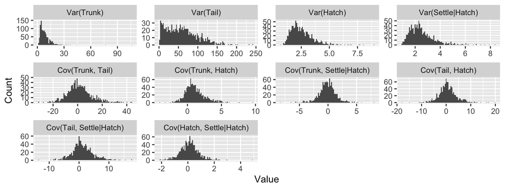

## V<sub>M</sub>

Latent scale

| metric | lower.hdi | median | mode | upper.hdi | pr.lt.hdi | pr.gt.hdi | 5pc.exceeds | pct.gt.0 |
| --- | --- | --- | --- | --- | --- | --- | --- | --- |
| Var(Trunk) | 5.642 | 15.98 | 14.81 | 31.89 | 0.01098 | 0.03892 | 30.4 | 0.999 |
| Var(Tail) | 53.55 | 125.5 | 120.1 | 224.2 | 0.01397 | 0.03593 | 215.2 | 1 |
| Var(Hatch) | -0.5711 | 0.1581 | 0.1822 | 1.047 | 0.02794 | 0.02196 | 0.8081 | 0.6846 |
| Var(Settle\|Hatch) | -0.6773 | 0.04681 | -0.001006 | 0.8906 | 0.02994 | 0.01996 | 0.6577 | 0.5519 |
| Cov(Trunk, Tail) | -0.364 | 21.41 | 16.39 | 49.88 | 0.01397 | 0.03593 | 47.61 | 0.982 |
| Cov(Trunk, Hatch) | -0.8887 | 1.002 | 0.7935 | 3.52 | 0.02395 | 0.02595 | 3.19 | 0.8453 |
| Cov(Trunk, Settle\|Hatch) | -1.656 | 0.2793 | 0.1699 | 2.818 | 0.02994 | 0.01996 | 2.256 | 0.5858 |
| Cov(Tail, Hatch) | -1.122 | 4.198 | 4.699 | 10.36 | 0.01597 | 0.03393 | 9.681 | 0.9521 |
| Cov(Tail, Settle\|Hatch) | -8.367 | -2.709 | -2.737 | 2.261 | 0.02695 | 0.02295 | 1.383 | 0.1437 |
| Cov(Hatch, Settle\|Hatch) | -0.7078 | -0.1455 | -0.1297 | 0.3553 | 0.02595 | 0.02395 | 0.2636 | 0.2774 |

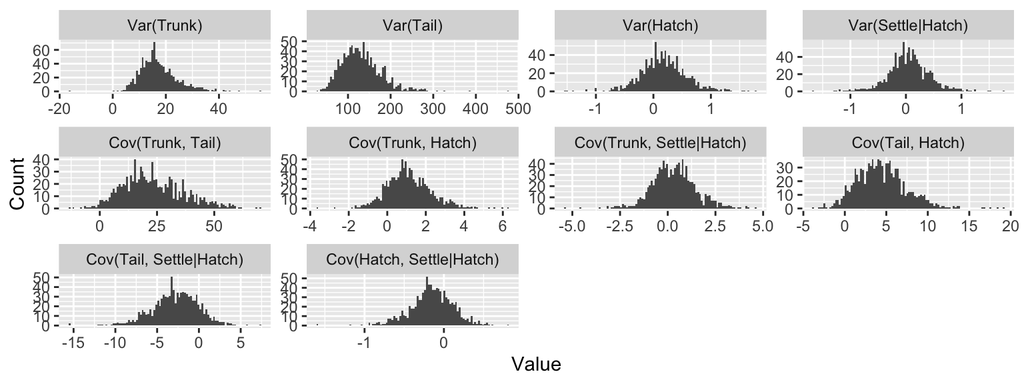

## V<sub>D</sub>

Latent scale

| metric | lower.hdi | median | mode | upper.hdi | pr.lt.hdi | pr.gt.hdi | 5pc.exceeds | pct.gt.0 |
| --- | --- | --- | --- | --- | --- | --- | --- | --- |
| Var(Trunk) | 1.495 | 7.596 | 5.575 | 19.46 | 0.000998 | 0.0489 | 19.42 | 1 |
| Var(Tail) | 1.39 | 19.08 | 10.47 | 124.1 | 0 | 0.0499 | 124.1 | 1 |
| Var(Hatch) | 0.9989 | 1.857 | 1.728 | 3.119 | 0.01497 | 0.03493 | 3.003 | 1 |
| Var(Settle\|Hatch) | 0.9643 | 1.737 | 1.633 | 2.796 | 0.00998 | 0.03992 | 2.724 | 1 |
| Cov(Trunk, Tail) | -13.43 | 2.206 | 1.005 | 30.07 | 0.01597 | 0.03393 | 26.59 | 0.6547 |
| Cov(Trunk, Hatch) | -2.616 | -0.2222 | -0.3381 | 1.631 | 0.01497 | 0.03493 | 1.401 | 0.4002 |
| Cov(Trunk, Settle\|Hatch) | -2.246 | -0.2095 | -0.07846 | 1.805 | 0.02994 | 0.01996 | 1.366 | 0.4002 |
| Cov(Tail, Hatch) | -3.847 | 0.3088 | 0.3049 | 5.634 | 0.02695 | 0.02295 | 4.683 | 0.5848 |
| Cov(Tail, Settle\|Hatch) | -5.115 | -0.4162 | -0.1405 | 2.774 | 0.02595 | 0.02395 | 2.243 | 0.3653 |
| Cov(Hatch, Settle\|Hatch) | -0.6048 | 0.1004 | 0.04405 | 0.8153 | 0.02495 | 0.02495 | 0.6933 | 0.6058 |

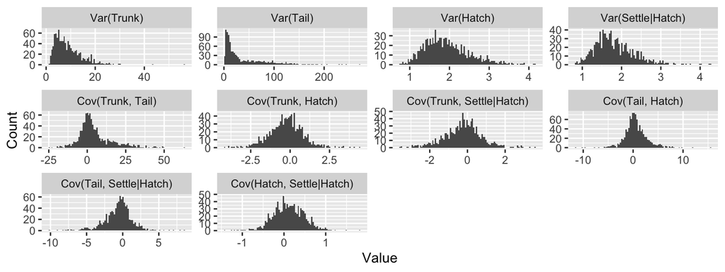

## V<sub>R</sub>

Latent scale

| metric | lower.hdi | median | mode | upper.hdi | pr.lt.hdi | pr.gt.hdi | 5pc.exceeds | pct.gt.0 |
| --- | --- | --- | --- | --- | --- | --- | --- | --- |
| Var(Trunk) | 81.45 | 88.96 | 88.22 | 97.08 | 0.02295 | 0.02695 | 95.63 | 1 |
| Var(Tail) | 305.3 | 332 | 330.5 | 362 | 0.02295 | 0.02695 | 358.3 | 1 |
| Var(Hatch) | 0 | 0 | 0 | 0 | 0 | 0 | 0 | 0 |
| Var(Settle\|Hatch) | 0 | 0 | 0 | 0 | 0 | 0 | 0 | 0 |
| Cov(Trunk, Tail) | 41 | 51.35 | 52.34 | 62.24 | 0.02595 | 0.02395 | 60.98 | 1 |
| Cov(Trunk, Hatch) | 0 | 0 | 0 | 0 | 0 | 0 | 0 | 0 |
| Cov(Trunk, Settle\|Hatch) | 0 | 0 | 0 | 0 | 0 | 0 | 0 | 0 |
| Cov(Tail, Hatch) | 0 | 0 | 0 | 0 | 0 | 0 | 0 | 0 |
| Cov(Tail, Settle\|Hatch) | 0 | 0 | 0 | 0 | 0 | 0 | 0 | 0 |
| Cov(Hatch, Settle\|Hatch) | 0 | 0 | 0 | 0 | 0 | 0 | 0 | 0 |

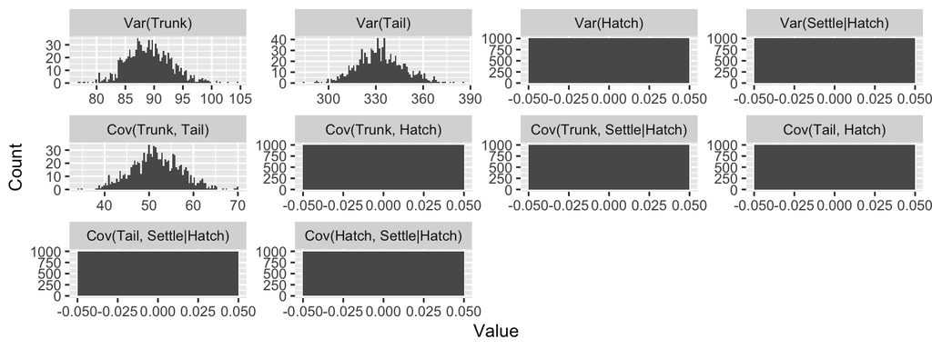

## V<sub>P</sub>

Latent scale

| metric | lower.hdi | median | mode | upper.hdi | pr.lt.hdi | pr.gt.hdi | 5pc.exceeds | pct.gt.0 |
| --- | --- | --- | --- | --- | --- | --- | --- | --- |
| Var(Trunk) | 99.43 | 111.9 | 111.2 | 128.7 | 0.01697 | 0.03293 | 126.6 | 1 |
| Var(Tail) | 422.2 | 498.1 | 486.7 | 601.5 | 0.01397 | 0.03593 | 590.8 | 1 |
| Var(Hatch) | 1.207 | 1.879 | 1.826 | 2.809 | 0.01198 | 0.03792 | 2.742 | 1 |
| Var(Settle\|Hatch) | 1.036 | 1.698 | 1.59 | 2.467 | 0 | 0.0499 | 2.466 | 1 |
| Cov(Trunk, Tail) | 50.86 | 76.04 | 76.32 | 105.5 | 0.01796 | 0.03194 | 102.1 | 1 |
| Cov(Trunk, Hatch) | -0.5457 | 1.516 | 1.445 | 3.961 | 0.02295 | 0.02695 | 3.69 | 0.9311 |
| Cov(Trunk, Settle\|Hatch) | -2.017 | 0.1478 | 0.0848 | 2.375 | 0.02096 | 0.02894 | 2.166 | 0.5509 |
| Cov(Tail, Hatch) | -1.179 | 4.618 | 4.358 | 10.85 | 0.01796 | 0.03194 | 10.24 | 0.9531 |
| Cov(Tail, Settle\|Hatch) | -7.773 | -2.247 | -2.374 | 2.777 | 0.02894 | 0.02096 | 1.715 | 0.1766 |
| Cov(Hatch, Settle\|Hatch) | -0.6372 | -0.05811 | -0.06597 | 0.4406 | 0.02096 | 0.02894 | 0.3835 | 0.4072 |

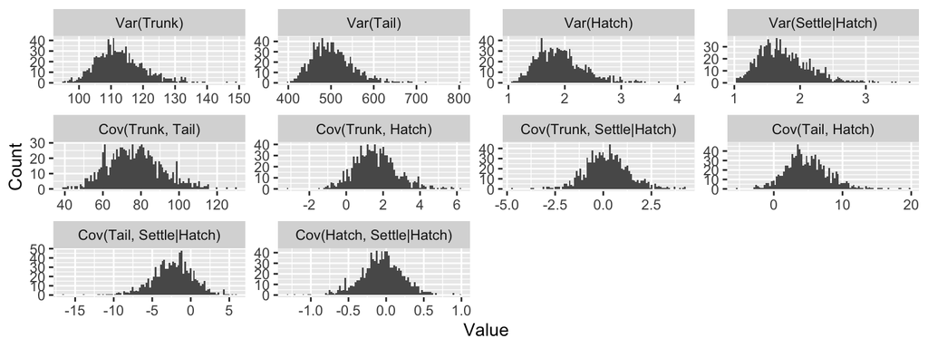

## V<sub>M</sub> / V<sub>A</sub>

Latent scale

| metric | lower.hdi | median | mode | upper.hdi | pr.lt.hdi | pr.gt.hdi | 5pc.exceeds | pct.gt.1 |
| --- | --- | --- | --- | --- | --- | --- | --- | --- |
| Var(Trunk) | 0.02707 | 2.385 | 1.444 | 7.723 | 0.000998 | 0.0489 | 7.669 | 0.8383 |
| Var(Tail) | 0.1928 | 2.531 | 1.586 | 22.39 | 0 | 0.0499 | 22.38 | 0.8593 |
| Var(Hatch) | -0.1542 | 0.06766 | 0.02161 | 0.4786 | 0.00998 | 0.03992 | 0.4535 | 0.002994 |
| Var(Settle\|Hatch) | -0.168 | 0.02154 | -0.03248 | 0.4127 | 0.008982 | 0.04092 | 0.387 | 0 |
| Cov(Trunk, Tail) | -45.31 | 0.2872 | 0.5893 | 45.91 | 0.03094 | 0.01896 | 19.33 | 0.4271 |
| Cov(Trunk, Hatch) | -19.5 | 0.44 | 0.6137 | 12.61 | 0.02096 | 0.02894 | 7.422 | 0.3483 |
| Cov(Trunk, Settle\|Hatch) | -11.26 | -0.2818 | -0.09675 | 8.324 | 0.02395 | 0.02595 | 4.51 | 0.1796 |
| Cov(Tail, Hatch) | -32.65 | 0.1543 | 0.1111 | 33.91 | 0.02994 | 0.01996 | 14.84 | 0.3453 |
| Cov(Tail, Settle\|Hatch) | -21.85 | -0.5191 | -0.6189 | 18.21 | 0.02295 | 0.02695 | 9.053 | 0.2156 |
| Cov(Hatch, Settle\|Hatch) | -4.231 | -0.2942 | -0.2922 | 3.346 | 0.01996 | 0.02994 | 2.273 | 0.08583 |

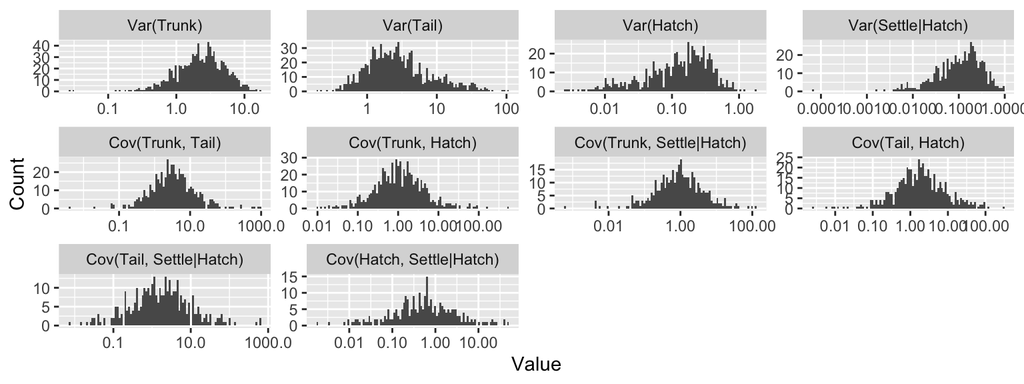

## V<sub>D</sub> / V<sub>A</sub>

Latent scale

| metric | lower.hdi | median | mode | upper.hdi | pr.lt.hdi | pr.gt.hdi | 5pc.exceeds | pct.gt.1 |
| --- | --- | --- | --- | --- | --- | --- | --- | --- |
| Var(Trunk) | 0.04949 | 1.045 | 0.6999 | 4.734 | 0 | 0.0499 | 4.734 | 0.523 |
| Var(Tail) | 0.01162 | 0.3165 | 0.1665 | 15.61 | 0 | 0.0499 | 15.58 | 0.3174 |
| Var(Hatch) | 0.1874 | 0.7737 | 0.6222 | 1.634 | 0 | 0.0499 | 1.633 | 0.3074 |
| Var(Settle\|Hatch) | 0.2355 | 0.7467 | 0.6888 | 1.599 | 0.003992 | 0.04591 | 1.586 | 0.2475 |
| Cov(Trunk, Tail) | -16.44 | -0.1573 | -0.1894 | 15.06 | 0.02794 | 0.02196 | 5.879 | 0.1717 |
| Cov(Trunk, Hatch) | -7.258 | -0.1258 | -0.1781 | 7.087 | 0.02495 | 0.02495 | 4.111 | 0.1537 |
| Cov(Trunk, Settle\|Hatch) | -7.556 | 0.009194 | -0.002194 | 7.604 | 0.02894 | 0.02096 | 3.823 | 0.1996 |
| Cov(Tail, Hatch) | -11.01 | 0.0007027 | -0.09893 | 13.79 | 0.02994 | 0.01996 | 5.528 | 0.2056 |
| Cov(Tail, Settle\|Hatch) | -11.84 | -0.03681 | -0.1323 | 11.07 | 0.01996 | 0.02994 | 5.465 | 0.1727 |
| Cov(Hatch, Settle\|Hatch) | -6.164 | 0.06382 | 0.1051 | 6.676 | 0.02395 | 0.02595 | 4.021 | 0.1906 |

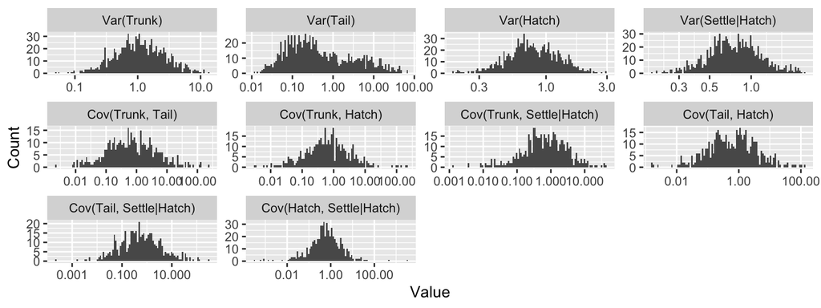

## Variance partitioning

Latent scale  
$(VA / VP) \times 100$

|  | Trunk | Tail |
| --- | --- | --- |
| **lower.hdi** | 1.4 | 0.5488 |
| **median** | 6.23 | 10.82 |
| **mode** | 4.641 | 5.773 |
| **upper.hdi** | 16.18 | 26.13 |
| **pr.lt.hdi** | 0.001996 | 0.002994 |
| **pr.gt.hdi** | 0.0479 | 0.04691 |
| **5pc.exceeds** | 16.1 | 26.01 |

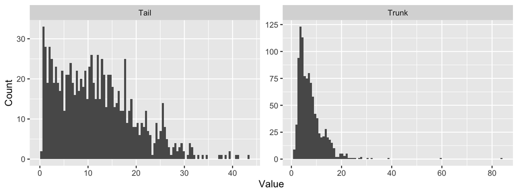

$(VM / VP) \times 100$

|  | Trunk | Tail |
| --- | --- | --- |
| **lower.hdi** | 6.574 | 12.54 |
| **median** | 14.54 | 25.27 |
| **mode** | 13.26 | 24.94 |
| **upper.hdi** | 26.67 | 38.25 |
| **pr.lt.hdi** | 0.02894 | 0.01497 |
| **pr.gt.hdi** | 0.02096 | 0.03493 |
| **5pc.exceeds** | 24.35 | 37.09 |

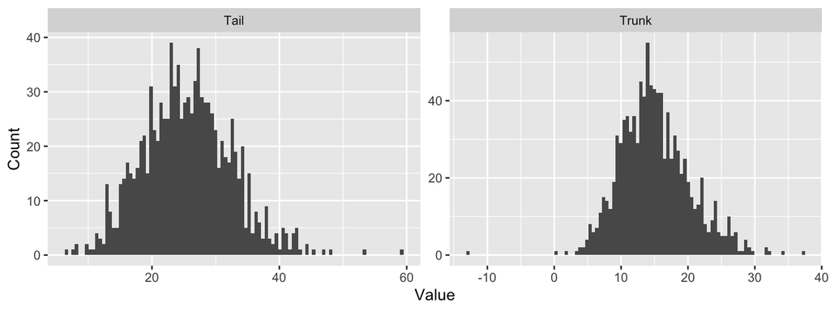

$(VD / VP) \times 100$

|  | Trunk | Tail |
| --- | --- | --- |
| **lower.hdi** | 1.473 | 0.2878 |
| **median** | 6.781 | 3.871 |
| **mode** | 4.971 | 2.19 |
| **upper.hdi** | 17.96 | 25.16 |
| **pr.lt.hdi** | 0.003992 | 0 |
| **pr.gt.hdi** | 0.04591 | 0.0499 |
| **5pc.exceeds** | 17.84 | 25.16 |

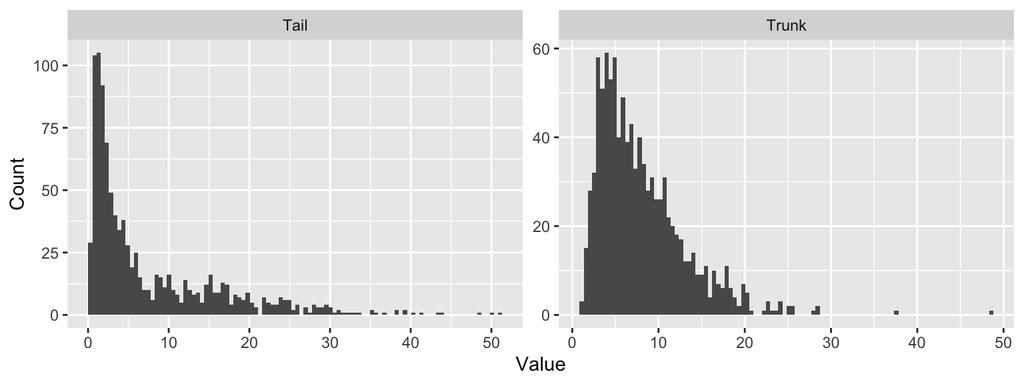

## Summarize QGmvparams posteriors

### Block means on expected data scale

Hatching actually measured in blocks 5, 7, 8, 9, 10, 11, 12, 13, 14, 16  
Settling actually measured in blocks 3, 4, 5, 7, 8, 9, 10, 11, 12, 14  
But **Block** has been re-coded for running model in runjags().

| Block | Stage | lower.hdi | median | mode | upper.hdi | pr.lt.hdi | pr.gt.hdi | 5pc.exceeds |
| --- | --- | --- | --- | --- | --- | --- | --- | --- |
| 3 | Hatch | NA | NA | NA | NA | NA | NA | NA |
| 4 | Hatch | NA | NA | NA | NA | NA | NA | NA |
| 5 | Hatch | 0.51 | 0.76 | 0.8 | 0.95 | 0.045 | 0.005 | 0.93 |
| 7 | Hatch | 0.52 | 0.76 | 0.78 | 0.95 | 0.046 | 0.004 | 0.91 |
| 8 | Hatch | 0.52 | 0.75 | 0.82 | 0.96 | 0.049 | 0.001 | 0.92 |
| 9 | Hatch | 0.63 | 0.86 | 0.9 | 0.96 | 0.048 | 0.002 | 0.95 |
| 10 | Hatch | 0.45 | 0.7 | 0.71 | 0.9 | 0.009 | 0.041 | 0.9 |
| 11 | Hatch | 0.45 | 0.71 | 0.73 | 0.9 | 0.011 | 0.039 | 0.89 |
| 12 | Hatch | 0.68 | 0.88 | 0.92 | 0.96 | 0.044 | 0.006 | 0.95 |
| 13 | Hatch | 0.53 | 0.78 | 0.8 | 0.95 | 0.043 | 0.007 | 0.92 |
| 14 | Hatch | 0.6 | 0.83 | 0.87 | 0.96 | 0.042 | 0.008 | 0.95 |
| 16 | Hatch | 0.72 | 0.9 | 0.93 | 0.97 | 0.05 | 0 | 0.96 |
| 3 | Settle\|Hatch | 0.48 | 0.8 | 0.88 | 0.96 | 0.049 | 0.001 | 0.94 |
| 4 | Settle\|Hatch | 0.56 | 0.82 | 0.89 | 0.97 | 0.049 | 0.001 | 0.95 |
| 5 | Settle\|Hatch | 0.41 | 0.72 | 0.78 | 0.96 | 0.047 | 0.003 | 0.93 |
| 7 | Settle\|Hatch | 0.59 | 0.85 | 0.91 | 0.97 | 0.048 | 0.002 | 0.95 |
| 8 | Settle\|Hatch | 0.44 | 0.74 | 0.8 | 0.95 | 0.043 | 0.007 | 0.92 |
| 9 | Settle\|Hatch | 0.31 | 0.63 | 0.64 | 0.87 | 0.004 | 0.046 | 0.87 |
| 10 | Settle\|Hatch | 0.33 | 0.66 | 0.75 | 0.91 | 0.026 | 0.024 | 0.88 |
| 11 | Settle\|Hatch | 0.33 | 0.63 | 0.6 | 0.89 | 0.024 | 0.026 | 0.87 |
| 12 | Settle\|Hatch | 0.36 | 0.64 | 0.7 | 0.91 | 0.039 | 0.011 | 0.86 |
| 13 | Settle\|Hatch | NA | NA | NA | NA | NA | NA | NA |
| 14 | Settle\|Hatch | 0.55 | 0.8 | 0.86 | 0.96 | 0.046 | 0.004 | 0.94 |
| 16 | Settle\|Hatch | NA | NA | NA | NA | NA | NA | NA |

Summary across blocks

| Stage | min | max | mean_median | mean_mode |
| --- | --- | --- | --- | --- |
| Hatch | 0.7 | 0.9 | 0.79 | 0.82 |
| Settle\|Hatch | 0.63 | 0.85 | 0.73 | 0.78 |

### Block means on latent scale

| Block | Hatch | Settle\|Hatch |
| --- | --- | --- |
| 3 | NA | 1.8 |
| 4 | NA | 2 |
| 5 | 1.6 | 1.3 |
| 7 | 1.6 | 2.2 |
| 8 | 1.6 | 1.4 |
| 9 | 2.3 | 0.77 |
| 10 | 1.2 | 0.85 |
| 11 | 1.2 | 0.78 |
| 12 | 2.5 | 0.81 |
| 13 | 1.7 | NA |
| 14 | 2.1 | 1.9 |
| 16 | 2.8 | NA |

### VA for settling and hatching on data scale across blocks

| Block | Stage | lower.hdi | median | mode | upper.hdi | pr.lt.hdi | pr.gt.hdi | 5pc.exceeds | pct.gt.0 |
| --- | --- | --- | --- | --- | --- | --- | --- | --- | --- |
| 1 | Var(Hatch) | 1.1 | 2.3 | 2.1 | 4.5 | 0.007 | 0.043 | 4.4 | 1 |
| 2 | Var(Hatch) | 1.1 | 2.3 | 2.1 | 4.5 | 0.007 | 0.043 | 4.4 | 1 |
| 3 | Var(Hatch) | 1.1 | 2.3 | 2.1 | 4.5 | 0.007 | 0.043 | 4.4 | 1 |
| 4 | Var(Hatch) | 1.1 | 2.3 | 2.1 | 4.5 | 0.007 | 0.043 | 4.4 | 1 |
| 5 | Var(Hatch) | 0.0023 | 0.044 | 0.038 | 0.11 | 0.001 | 0.049 | 0.11 | 1 |
| 7 | Var(Hatch) | 0.0029 | 0.044 | 0.032 | 0.1 | 0 | 0.05 | 0.1 | 1 |
| 8 | Var(Hatch) | 0.0033 | 0.046 | 0.035 | 0.11 | 0.002 | 0.048 | 0.11 | 1 |
| 9 | Var(Hatch) | 0.0012 | 0.022 | 0.012 | 0.081 | 0.001 | 0.049 | 0.081 | 1 |
| 10 | Var(Hatch) | 0.0062 | 0.054 | 0.052 | 0.12 | 0.01 | 0.04 | 0.11 | 1 |
| 11 | Var(Hatch) | 0.0083 | 0.055 | 0.051 | 0.12 | 0.011 | 0.039 | 0.11 | 1 |
| 12 | Var(Hatch) | 0.0015 | 0.018 | 0.011 | 0.072 | 0.003 | 0.047 | 0.071 | 1 |
| 13 | Var(Hatch) | 0.0026 | 0.043 | 0.028 | 0.099 | 0.003 | 0.047 | 0.098 | 1 |
| 14 | Var(Hatch) | 0.0014 | 0.03 | 0.017 | 0.087 | 0.003 | 0.047 | 0.087 | 1 |
| 15 | Var(Hatch) | 1.1 | 2.3 | 2.1 | 4.5 | 0.007 | 0.043 | 4.4 | 1 |
| 16 | Var(Hatch) | 0.00096 | 0.013 | 0.0077 | 0.06 | 0 | 0.05 | 0.06 | 1 |
| 1 | Var(Settle\|Hatch) | 0.95 | 2.3 | 2 | 4.5 | 0.001 | 0.049 | 4.5 | 1 |
| 2 | Var(Settle\|Hatch) | 0.95 | 2.3 | 2 | 4.5 | 0.001 | 0.049 | 4.5 | 1 |
| 3 | Var(Settle\|Hatch) | 0.0017 | 0.037 | 0.02 | 0.1 | 0 | 0.05 | 0.1 | 1 |
| 4 | Var(Settle\|Hatch) | 0.0018 | 0.031 | 0.017 | 0.096 | 0.003 | 0.047 | 0.095 | 1 |
| 5 | Var(Settle\|Hatch) | 0.002 | 0.051 | 0.055 | 0.11 | 0.002 | 0.048 | 0.11 | 1 |
| 7 | Var(Settle\|Hatch) | 0.0015 | 0.026 | 0.014 | 0.093 | 0.001 | 0.049 | 0.093 | 1 |
| 8 | Var(Settle\|Hatch) | 0.0029 | 0.049 | 0.047 | 0.11 | 0.003 | 0.047 | 0.11 | 1 |
| 9 | Var(Settle\|Hatch) | 0.0051 | 0.063 | 0.058 | 0.12 | 0.006 | 0.044 | 0.12 | 1 |
| 10 | Var(Settle\|Hatch) | 0.0061 | 0.059 | 0.061 | 0.12 | 0.002 | 0.048 | 0.12 | 1 |
| 11 | Var(Settle\|Hatch) | 0.0069 | 0.062 | 0.065 | 0.12 | 0.005 | 0.045 | 0.12 | 1 |
| 12 | Var(Settle\|Hatch) | 0.0064 | 0.062 | 0.057 | 0.12 | 0.002 | 0.048 | 0.12 | 1 |
| 13 | Var(Settle\|Hatch) | 0.95 | 2.3 | 2 | 4.5 | 0.001 | 0.049 | 4.5 | 1 |
| 14 | Var(Settle\|Hatch) | 0.0018 | 0.036 | 0.019 | 0.098 | 0.002 | 0.048 | 0.097 | 1 |
| 15 | Var(Settle\|Hatch) | 0.95 | 2.3 | 2 | 4.5 | 0.001 | 0.049 | 4.5 | 1 |
| 16 | Var(Settle\|Hatch) | 0.95 | 2.3 | 2 | 4.5 | 0.001 | 0.049 | 4.5 | 1 |

[output cut: 75 more lines]

### VP for settling and hatching on data scale across blocks

| Block | Stage | lower.hdi | median | mode | upper.hdi | pr.lt.hdi | pr.gt.hdi | 5pc.exceeds | pct.gt.0 |
| --- | --- | --- | --- | --- | --- | --- | --- | --- | --- |
| 1 | Var(Hatch) | 1.2 | 1.9 | 1.8 | 2.8 | 0.012 | 0.038 | 2.7 | 1 |
| 2 | Var(Hatch) | 1.2 | 1.9 | 1.8 | 2.8 | 0.012 | 0.038 | 2.7 | 1 |
| 3 | Var(Hatch) | 1.2 | 1.9 | 1.8 | 2.8 | 0.012 | 0.038 | 2.7 | 1 |
| 4 | Var(Hatch) | 1.2 | 1.9 | 1.8 | 2.8 | 0.012 | 0.038 | 2.7 | 1 |
| 5 | Var(Hatch) | 0.066 | 0.18 | 0.22 | 0.25 | 0.05 | 0 | 0.25 | 1 |
| 7 | Var(Hatch) | 0.079 | 0.18 | 0.22 | 0.25 | 0.05 | 0 | 0.25 | 1 |
| 8 | Var(Hatch) | 0.075 | 0.19 | 0.22 | 0.25 | 0.05 | 0 | 0.25 | 1 |
| 9 | Var(Hatch) | 0.038 | 0.12 | 0.097 | 0.24 | 0.01 | 0.04 | 0.23 | 1 |
| 10 | Var(Hatch) | 0.091 | 0.21 | 0.23 | 0.25 | 0.05 | 0 | 0.25 | 1 |
| 11 | Var(Hatch) | 0.098 | 0.21 | 0.23 | 0.25 | 0.05 | 0 | 0.25 | 1 |
| 12 | Var(Hatch) | 0.035 | 0.11 | 0.084 | 0.22 | 0.006 | 0.044 | 0.22 | 1 |
| 13 | Var(Hatch) | 0.071 | 0.17 | 0.21 | 0.25 | 0.05 | 0 | 0.25 | 1 |
| 14 | Var(Hatch) | 0.052 | 0.14 | 0.13 | 0.25 | 0.05 | 0 | 0.24 | 1 |
| 15 | Var(Hatch) | 1.2 | 1.9 | 1.8 | 2.8 | 0.012 | 0.038 | 2.7 | 1 |
| 16 | Var(Hatch) | 0.032 | 0.091 | 0.066 | 0.2 | 0 | 0.05 | 0.2 | 1 |
| 1 | Var(Settle\|Hatch) | 1 | 1.7 | 1.6 | 2.5 | 0 | 0.05 | 2.5 | 1 |
| 2 | Var(Settle\|Hatch) | 1 | 1.7 | 1.6 | 2.5 | 0 | 0.05 | 2.5 | 1 |
| 3 | Var(Settle\|Hatch) | 0.056 | 0.16 | 0.2 | 0.25 | 0.049 | 0.001 | 0.25 | 1 |
| 4 | Var(Settle\|Hatch) | 0.051 | 0.15 | 0.14 | 0.25 | 0.05 | 0 | 0.25 | 1 |
| 5 | Var(Settle\|Hatch) | 0.069 | 0.2 | 0.23 | 0.25 | 0.05 | 0 | 0.25 | 1 |
| 7 | Var(Settle\|Hatch) | 0.047 | 0.13 | 0.091 | 0.25 | 0.05 | 0 | 0.24 | 1 |
| 8 | Var(Settle\|Hatch) | 0.071 | 0.19 | 0.22 | 0.25 | 0.05 | 0 | 0.25 | 1 |
| 9 | Var(Settle\|Hatch) | 0.12 | 0.23 | 0.24 | 0.25 | 0.05 | 0 | 0.25 | 1 |
| 10 | Var(Settle\|Hatch) | 0.1 | 0.22 | 0.24 | 0.25 | 0.05 | 0 | 0.25 | 1 |
| 11 | Var(Settle\|Hatch) | 0.11 | 0.23 | 0.24 | 0.25 | 0.05 | 0 | 0.25 | 1 |
| 12 | Var(Settle\|Hatch) | 0.12 | 0.23 | 0.24 | 0.25 | 0.05 | 0 | 0.25 | 1 |
| 13 | Var(Settle\|Hatch) | 1 | 1.7 | 1.6 | 2.5 | 0 | 0.05 | 2.5 | 1 |
| 14 | Var(Settle\|Hatch) | 0.056 | 0.16 | 0.2 | 0.25 | 0.049 | 0.001 | 0.25 | 1 |
| 15 | Var(Settle\|Hatch) | 1 | 1.7 | 1.6 | 2.5 | 0 | 0.05 | 2.5 | 1 |
| 16 | Var(Settle\|Hatch) | 1 | 1.7 | 1.6 | 2.5 | 0 | 0.05 | 2.5 | 1 |

[output cut: 75 more lines]

## Genetic selection gradients

$\boldsymbol{\beta}_{g} = \mathbf{G}^{-1}\mathbf{s}_{g}$

## Evolvability (for single traits)

|  | Trunk | Tail |
| --- | --- | --- |
| **lower.hdi** | 0.00003248 | 0.00001083 |
| **median** | 0.00017 | 0.0002666 |
| **mode** | 0.0001318 | 0.0001474 |
| **upper.hdi** | 0.0004334 | 0.0006469 |
| **pr.lt.hdi** | 0.000998 | 0.000998 |
| **pr.gt.hdi** | 0.0489 | 0.0489 |
| **5pc.exceeds** | 0.0004331 | 0.0006442 |

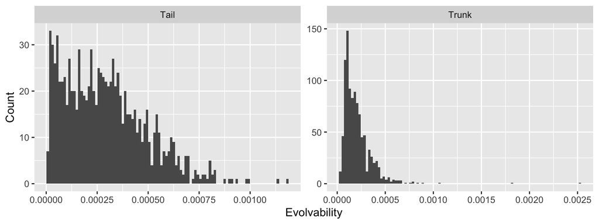

Evolvability as a percentage

|  | Trunk | Tail |
| --- | --- | --- |
| **lower.hdi** | 0.003248 | 0.001083 |
| **median** | 0.017 | 0.02666 |
| **mode** | 0.01318 | 0.01474 |
| **upper.hdi** | 0.04334 | 0.06469 |
| **pr.lt.hdi** | 0.000998 | 0.000998 |
| **pr.gt.hdi** | 0.0489 | 0.0489 |
| **5pc.exceeds** | 0.04331 | 0.06442 |

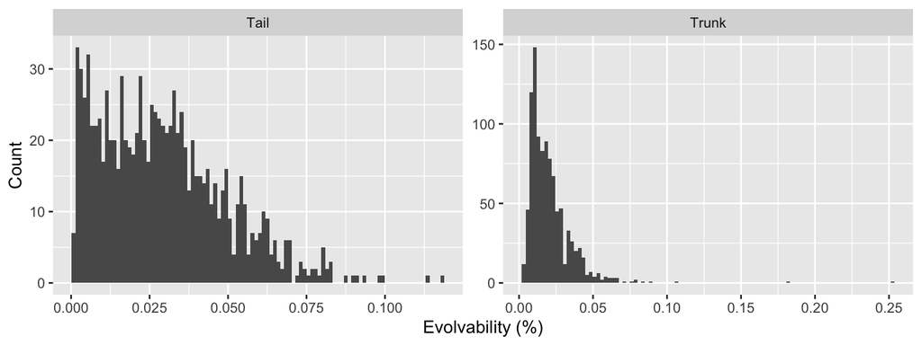

## Tail / Trunk Evolvability

| lower.hdi | median | mode | upper.hdi | pr.lt.hdi | pr.gt.hdi | 5pc.exceeds |
| --- | --- | --- | --- | --- | --- | --- |
| 0.088 | 1.472 | 1.996 | 6.976 | 1.02 | 1.03 | 5.64 |

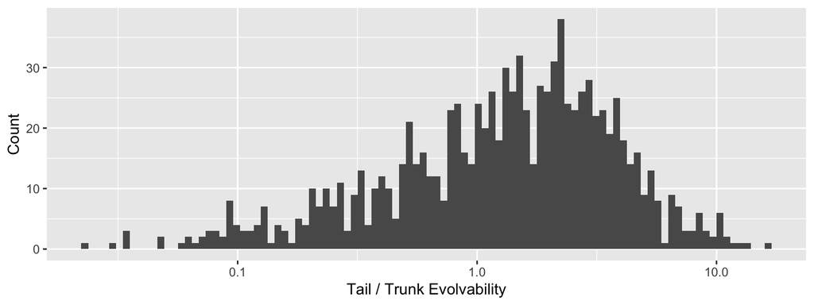

## Evolvability (from G matrix) Approach 1

This is for a random set of selection gradients.  
Multiply eB by 100 to get in units of percent.

| name | lower.hdi | median | mode | upper.hdi | pr.lt.hdi | pr.gt.hdi | 5pc.exceeds |
| --- | --- | --- | --- | --- | --- | --- | --- |
| eB | 0.000013 | 0.000128 | 0.000095 | 0.000295 | 0.002994 | 0.04691 | 0.000293 |
| rB | 0.000013 | 0.000149 | 0.000085 | 0.00036 | 0.002994 | 0.04691 | 0.000354 |
| cB | 0.000014 | 0.000069 | 0.000054 | 0.000149 | 0.005988 | 0.04391 | 0.000144 |
| iB | 0.04907 | 0.4261 | 0.5033 | 0.723 | 0.03094 | 0.01896 | 0.6821 |
| aB | 0.277 | 0.5739 | 0.4967 | 0.9509 | 0.01896 | 0.03094 | 0.934 |

## Evolvability (from G matrix) Approach 2

This is for a specific set of selection gradients:  
Beta_index = 1 is $\beta = \begin{bmatrix} 0 \\ 1 \end{bmatrix}$ = strong selection for longer tails only  
Beta_index = 2 is $\beta = \begin{bmatrix} -(1/\sqrt2) \\ -(1/\sqrt2) \end{bmatrix}$ = strong selection for shorter trunks and shorter tails  
Beta_index = 3 is $\beta = \begin{bmatrix} (1/\sqrt2) \\ -(1/\sqrt2) \end{bmatrix}$ = strong selection for longer trunks and shorter tails  
Multiply ‘evolvability’ by 100 to get in units of percent.

| Beta_index | metric | lower.hdi | median | mode | upper.hdi | pr.lt.hdi | pr.gt.hdi | 5pc.exceeds |
| --- | --- | --- | --- | --- | --- | --- | --- | --- |
| 1 | evolvability | 0.000011 | 0.000267 | 0.000147 | 0.000647 | 0.000998 | 0.0489 | 0.000644 |
| 2 | evolvability | 0.000024 | 0.000218 | 0.000143 | 0.00063 | 0.000998 | 0.0489 | 0.000629 |
| 3 | evolvability | 0.000022 | 0.000207 | 0.00016 | 0.000482 | 0 | 0.0499 | 0.000482 |
| 1 | respondability | 0.000018 | 0.000282 | 0.000173 | 0.000704 | 0.003992 | 0.04591 | 0.000698 |
| 2 | respondability | 0.00003 | 0.000245 | 0.000161 | 0.000672 | 0.001996 | 0.0479 | 0.00067 |
| 3 | respondability | 0.000029 | 0.000236 | 0.000191 | 0.000538 | 0.001996 | 0.0479 | 0.000532 |
| 1 | conditional | 0.000006 | 0.000207 | 0.000108 | 0.000549 | 0 | 0.0499 | 0.000549 |
| 2 | conditional | 0.000007 | 0.000156 | 0.000097 | 0.000494 | 0 | 0.0499 | 0.000494 |
| 3 | conditional | 0.000014 | 0.000146 | 0.000106 | 0.000399 | 0.000998 | 0.0489 | 0.000397 |
| 1 | autonomy (cB/eB) | 0.426 | 0.8802 | 0.9403 | 1 | 0.0499 | 0 | 0.9984 |
| 2 | autonomy (cB/eB) | 0.3112 | 0.8194 | 0.9101 | 1 | 0.0499 | 0 | 0.9977 |
| 3 | autonomy (cB/eB) | 0.3112 | 0.8194 | 0.9101 | 1 | 0.0499 | 0 | 0.9977 |
| 1 | integration | 0.000001 | 0.1198 | 0.05969 | 0.574 | 0 | 0.0499 | 0.574 |
| 2 | integration | 0.000001 | 0.1806 | 0.08992 | 0.6888 | 0 | 0.0499 | 0.6887 |
| 3 | integration | 0.000001 | 0.1806 | 0.08992 | 0.6888 | 0 | 0.0499 | 0.6887 |

## Response to selection (%) from covariance. Approach 3

| param | lower.hdi | median | mode | upper.hdi | pr.lt.hdi | pr.gt.hdi | 5pc.exceeds |
| --- | --- | --- | --- | --- | --- | --- | --- |
| Tail : Settle\|Hatch | -0.3665 | 0.0283 | 0.01783 | 0.4981 | 0.01776 | 0.03214 | 0.417 |
| Trunk : Settle\|Hatch | -0.4161 | -0.009657 | -0.006509 | 0.3654 | 0.02385 | 0.02605 | 0.2747 |
| Tail : Hatch | -0.3181 | 0.008949 | 0.009459 | 0.351 | 0.01507 | 0.03483 | 0.3005 |
| Trunk : Hatch | -0.159 | 0.05716 | 0.03834 | 0.4305 | 0.01467 | 0.03523 | 0.3764 |

## Total response to selection (%) from covariance

| param | lower.hdi | median | mode | upper.hdi | pr.lt.hdi | pr.gt.hdi | 5pc.exceeds |
| --- | --- | --- | --- | --- | --- | --- | --- |
| Tail | -0.4505 | 0.05439 | 0.04098 | 0.7299 | 0.02221 | 0.02769 | 0.5809 |
| Trunk | -0.4037 | 0.0558 | 0.03966 | 0.6498 | 0.02108 | 0.02882 | 0.5349 |